# A simple model of reputation

*Nick Janetos*

*December 5th, 2015*

## Introduction

I consider a simple dynamic model of reputation. A continuum of long-lived sellers interact with a continuum of short-lived buyers, while choosing (at some cost) a quality level. The buyers observe only the rating and price of a seller, and from that draw some inference. I look for stationary separating equilibria, meaning equilibria in which buyers correctly infer the quality of a seller jointly from his price and rating, and the joint distribution of prices and ratings is stationary over time (although individual sellers may change their price or quality choice.)

## Model description

Time is continuous, $t \in \mathbb{R}_+$. A unit mass of long-lived sellers interact with a unit mass of short-lived buyers. Before the game begins, each seller receives an exogenously granted rating, $r_0$, drawn iid from $\tilde{r}_0$ taking values in $[\underline{r}, \overline{r}]$. In each instant $t$, the sequence of actions proceeds as follows:

1. At time $t$, a seller, $i$, observes his current rating, $r_i(t)$.
2. Seller $i$ then chooses a quality level, $\theta_i(t)$, and a price, $p_i(t)$.
3. Each buyer then observes all the joint prices and ratings, $\{(r_i(t), p_i(t))\}_{i \in [0, 1]}$. But, buyers do not observe the quality, $\theta_i(t)$.
4. Each buyer then chooses a seller from whom to buy. I assume that buyers split their business equally between identical sellers, therefore, the density of buyers buying from a seller with rating $r$ and price $p$ is independent of $i$ and denoted by $m(r, p)$.

The instantaneous payoff of a seller with rating $r$ offering price $p$ is given by

\begin{equation} \label{eq:sellerpayoff} U(r, p) = m(r, p)(p - k \theta), \end{equation}

where $k \in \mathbb{R}_+$ is some cost parameter. A buyer who purchases from a seller with quality $\theta$ at price $p$ receives a realized payoff of

\begin{equation} \label{eq:buyerpayoff} V(\theta, p) = \frac{\theta}{w} - p, \end{equation}

where here $w$ is drawn iid across buyers from some random variable $\tilde{w}$ taking values in $[0, 1]$. The random variable $w$ is a taste parameter which measures how important quality is to a buyer relative to the price.

Each seller chooses a path for quality and prices, $\{\theta_i(t), p_i(t)\}_{t \in \mathbb{R}}$, processes measurable with respect to the path of ratings, $\{r_i(t)\}_{t \in \mathbb{R}_+}$. I restrict attention to symmetric Markov strategies, that is, the complete strategy profile is represented by $\theta(r), p(r)$, mapping the current rating of a seller into an action choice.

Ratings for a seller evolve according to the law of motion

\begin{equation} \label{eq:lawofmotion} \dot{r}(t) = \gamma_0 \times m(r(t), p(t)) \times \big(\theta(t) - r(t)\big), \end{equation}

with initial condition $r_0$. That is, a seller's rating is an exponentially weighted moving average of past quality levels, with weight $\gamma_0 m(r(t), p(t))$. The more buyers buy from a seller, the faster his rating adjusts to reflect his current choice of quality.

I focus on symmetric Markov strategies, and so omit the dependence on $i$ for much of the rest of this draft. A seller solves

\begin{align*} \max_{\theta, p} & \int_0^\infty e^{-\gamma_1 t} m(r(t), p(t)) (p(t) - k_0 \theta(t)) \,dt \\\ \text{s.t. } \hspace{0.05in} & \dot{r}(t) = \gamma_0 m(r(t), p(t)) (\theta(t) - r(t)) \\\ & r(0) = r_0. \end{align*}

Let $V(r)$ denote the value of this problem for a given rating $r$. Let $V(t, r)$ denote the continuation value at time $t$ for a given rating $r$.

We seek stationary symmetric equilibria, meaning one in which all sellers choose $\theta(t) = r_0$ for all $t$. Assume that $\tilde{r}_0$, the distribution over initial ratings, is represented by a density function $f_r(r)$, and assume it is positive on $[0, 1]$.

## Analysis

### Firm's problem

The first observation is that our stationarity assumption implies the value function is linear in $r$. To see this, write the Hamilton-Jacobi-Bellman equation,

\begin{equation} V_t(t, r) + \max_{\theta} V_r(t, r) \gamma_0 m(r, p(r)) (\theta - r) + m(r, p(t)) (p(r) - k \theta) = 0. \end{equation}

The maximand is linear in $\theta$, so its solution is

\begin{equation} \theta^*(r) \in \begin{cases} \{1\} & V_r(t, r) > \frac{k}{\gamma_0} \\\ [0, 1] & V_r(t, r) = \frac{k}{\gamma_0} \\\ \{0\} & V_r(t, r) < \frac{k}{\gamma_0}.\end{cases} \end{equation}

The value function is continuous, hence if there were a rating at which sellers strictly preferred to choose 1, then since $\tilde{r}_0$ has full support on $[\underline{r}, \overline{r}]$, there would be a positive measure of sellers who prefer to choose 1, and by our stationarity assumption $\tilde{r}_0$ would have an atom at $r_0 = 1$, which contradicts the assumption that the probability measure on $\tilde{r}_0$ is represented by a density function.

Therefore, all sellers are indifferent between quality choices, so $V_r = \frac{k}{\gamma_0}$, and so $V(r) = \frac{k}{\gamma_0} r + V(0)$. Assume that nobody buys at $r = 0$, so that $V(0) = 0$. (This is to some extent a normalization.)

At the same time, by the stationarity assumption,

\begin{align*} V(r) & = \int_0^\infty e^{-\gamma_1 t} m(r(t), p(r(t))) (p(r(r)) - k \theta(t)) \,dt \\ & = \int_0^\infty e^{-\gamma_1 t} m(r, p(r)) (p(r) - k r) \,dt \\ & = \frac{1}{\gamma_1}m(r) (p(r) - kr), \end{align*}

where $m(r) := m(r, p(r))$. Equating terms, the price function is

\begin{equation} \label{eq:price} p(r) = r \times \left(k + \frac{\gamma_1 k}{\gamma_0} m(r)^{-1}\right). \end{equation}

The price function, \eqref{eq:price}, equals the marginal cost of maintaining a quality level, $k r$, plus some signaling rents which accrue to prevent a seller from choosing a zero quality, then 'coasting' on their built up reputation for a while. The rents are proportional to $\gamma_1$, the impatience of the seller, $k$, the cost of maintaining a high reputation, and $r$, the rating which needs to be maintained. They are inversely proportional to the number of people buying from the seller, since if lots of people are buying from a seller, their rating falls faster when they shirk.

### The buyer's problem

Assume that a buyer's payoff is given by

\begin{equation*} V(r, p) = \frac{\nu_0}{w} r - p. \end{equation*}

Faced with a price function, $p(r)$, given by \eqref{eq:price}, a buyer solves

\begin{equation*} \max_r \frac{\nu_0}{w} r - p(r). \end{equation*}

The first order conditions are

\begin{equation*} \frac{\nu_0}{w} = k_0 + \frac{\gamma k_0}{m(r)} - r \gamma k_0 \frac{m'(r)}{m(r)^2}. \end{equation*}

This determines $r(w)$, a buyer with taste preference $w$ optimal quality choice. Therefore, for a given $m(r)$, there is (are) candidate(s) $r(w)$ which solve the problem. A change of variables formula then implies

\begin{equation*} m(r) = \frac{f(r^{-1}(r))}{r'(r^{-1}(r))}, \end{equation*}

that is, given $m(r)$, one can back out a distribution $f(w)$ over the taste parameter. Presumably under appropriate monotonicity / continuity assumptions this distribution is unique. Similarly, given $f(w)$, one can derive $m(r)$.

## Data

```python
# Load the data↔
```

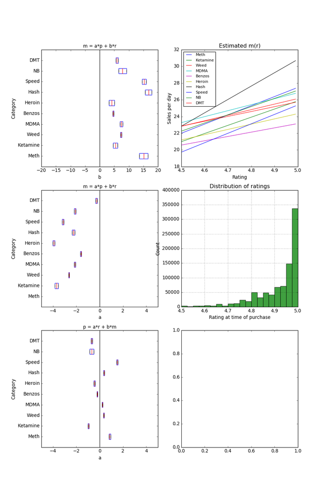

```python
# Build graphs↔
```

```python
# Hide stuff
from IPython.display import HTML
import warnings

warnings.filterwarnings('ignore')
HTML('''<script>$('div.input').hide();</script>''')
```

## References

### Empirical research on online reputations

[Resnick, Paul, and Richard Zeckhauser. "Trust among strangers in internet transactions: Empirical analysis of ebay’s reputation system." The Economics of the Internet and E-commerce 11.2 (2002): 23-25.](http://presnick.people.si.umich.edu/papers/ebayNBER/RZNBERBodegaBay.pdf)

[Melnik, Mikhail I., and James Alm. "Does a seller's ecommerce reputation matter? Evidence from eBay auctions." Journal of Industrial Economics (2002): 337-349.](http://www.jstor.org/stable/3569809)

[McDonald, Cynthia G., and V. Carlos Slawson. "Reputation in an internet auction market." Economic inquiry 40.4 (2002): 633-650.](http://onlinelibrary.wiley.com/doi/10.1093/ei/40.4.633/abstract)

[Hubbard, Thomas N. "How Do Consumers Motivate Experts? Reputational Incentives in an Auto Repair Market*." Journal of Law and Economics 45.2 (2002): 437-468.](http://www.jstor.org/stable/10.1086/340086)

[Ba, Sulin, and Paul A. Pavlou. "Evidence of the effect of trust building technology in electronic markets: Price premiums and buyer behavior." MIS quarterly (2002): 243-268.](http://oz.stern.nyu.edu/rr2001/emkts/ba.pdf)

[Dewan, Sanjeev, and Vernon Hsu. "Adverse selection in electronic markets: Evidence from online stamp auctions." The Journal of Industrial Economics 52.4 (2004): 497-516.](http://www.jstor.org/stable/3569860?seq=1#page_scan_tab_contents)

[Eaton, David H. "Reputation effects in online auction markets." Available at SSRN 739765 (2005).](http://papers.ssrn.com/soL3/papers.cfm?abstract_id=739765)

[Resnick, Paul, et al. "The value of reputation on eBay: A controlled experiment." Experimental Economics 9.2 (2006): 79-101.](http://link.springer.com/article/10.1007%2Fs10683-006-4309-2)

[Brown, Jennifer, and John Morgan. "Reputation in online markets: Some negative feedback." University of California, Berkeley (2006).](http://faculty.haas.berkeley.edu/rjmorgan/reputation%20in%20online%20markets.pdf)

[Houser, Daniel, and John Wooders. "Reputation in auctions: Theory, and evidence from eBay." Journal of Economics & Management Strategy 15.2 (2006): 353-369.](http://onlinelibrary.wiley.com/doi/10.1111/j.1530-9134.2006.00103.x/full)

[Jin, Ginger Zhe, and Andrew Kato. "Price, quality, and reputation: Evidence from an online field experiment." The RAND Journal of Economics 37.4 (2006): 983-1005.](http://onlinelibrary.wiley.com/doi/10.1111/j.1756-2171.2006.tb00067.x/abstract)

[Pavlou, Paul A., and Angelika Dimoka. "The nature and role of feedback text comments in online marketplaces: Implications for trust building, price premiums, and seller differentiation." Information Systems Research 17.4 (2006): 392-414.](http://pubsonline.informs.org/doi/abs/10.1287/isre.1060.0106)

[Jin, Ginger Zhe, and Phillip Leslie. "Reputational incentives for restaurant hygiene." American Economic Journal: Microeconomics 1.1 (2009): 237-267.](https://www.aeaweb.org/articles.php?doi=10.1257/mic.1.1.237)

[Cabral, Luis, and Ali Hortacsu. "The dynamics of seller reputation: Evidence from ebay*." The Journal of Industrial Economics 58.1 (2010): 54-78.](http://onlinelibrary.wiley.com/doi/10.1111/j.1467-6451.2010.00405.x/full)

[Canals-Cerdá, José J. "The value of a good reputation online: an application to art auctions." Journal of Cultural Economics 36.1 (2012): 67-85.](http://link.springer.com/article/10.1007/s10824-011-9156-0)

[Yoganarasimhan, Hema. "The value of reputation in an online freelance marketplace." Marketing Science 32.6 (2013): 860-891.](http://pubsonline.informs.org/doi/abs/10.1287/mksc.2013.0809)

[Cabral, Luís. "Reputation on the Internet." The Oxford Handbook of the Digital Economy (2012): 343-354.](http://luiscabral.net/economics/workingpapers/13_Peitz_Ch13.pdf)